# **Conuma terminal run reconstruction**

Last update: 2022-10-20

# 1 **Introduction**

*This can be amended - taken from original Excel file*

The objectives are to:

1. Estimate **terminal returns** to the area **by age**. The age breakdown is essential for Chinook forecasting and modelling
2. Estimate the **hatchery contribution** to the terminal runs
3. Estimate the potential **egg deposition**. For Chinook, we are defining escapement targets by eggs due to the variable age-at-return and variable contribution of females to spawner totals.
4. Estimate terminal **harvest rates**

Data sources include:

- Catch data:
  - Sport age data: from ‘BIOCNxxx.xlsx’ files. Ages pooled over sub-areas and weighted by stat week sample size.
  - Sport termal mark data: from ’2013 - X:_MARK_PROJECT_25_2009to2013Chinook_Bio_Recreational_Crest_oto_age.xlsx’ files.
- Escapement data:
  - Query escapement and broodstock estimates from New Escapement Index.xls or from Escapement Coordinator’s PDF summaries.
  - Query escapement age data from NuSEDs; cross check with WCVI files for additional data not entered into NuSEDs; sample N is usually higher than for otolith-linked biodata; ages are uncorrected for sex stratified sampling; for RunRecon years, these data were used to calculate age, rather than pulling from PADs directly
  - If otolith data are available and linked to biodata, summarize to determine % marked by age; summarize further to determine % marked by age and sex.
  - Correct escapement sample age data for sex-stratified sampling:
    - Determine sex at age proportions from biodata
    - Use first set sex ratio data from hatchery staff (Conuma) to calculate correction factors
    - Note: do not correct broodstock age ratio as the hatchery uses 3:3 males:females when spawning (more similar to the sex stratified sample)

# 2 **Study area**

[figure not shown]

Conuma terminal run reconstruction study area

# 3 **Data exploration**

## 3.1 **Spatial data**

Spatial distribution of chinook catch in commerical (red), EO (navy), and sport (gold) fisheries scaled by size bins (<500, 500-999, 1000-1499, and >1500. Catch data are overlaid by available biosample data (green rings), with size scaled based on available sample size

### 3.1.1 2021 catch + biodata

Catch here is from 2021 and overlaid with 2021 biosamples.

[interactive chart not shown]

### 3.1.2 2021 catch + 2020 biodata

Catch here is from 2021 and overlaid with 2020 biosamples.

[interactive chart not shown]

### 3.1.3 2021 catch + 2019 biodata

Catch here is from 2021 and overlaid with 2019 biosamples.

[interactive chart not shown]

### 3.1.4 2021 catch + 2018 biodata

Catch here is from 2021 and overlaid with 2018 biosamples.

[interactive chart not shown]

## 3.2 **Temporal data**

Temporal distribution of catch

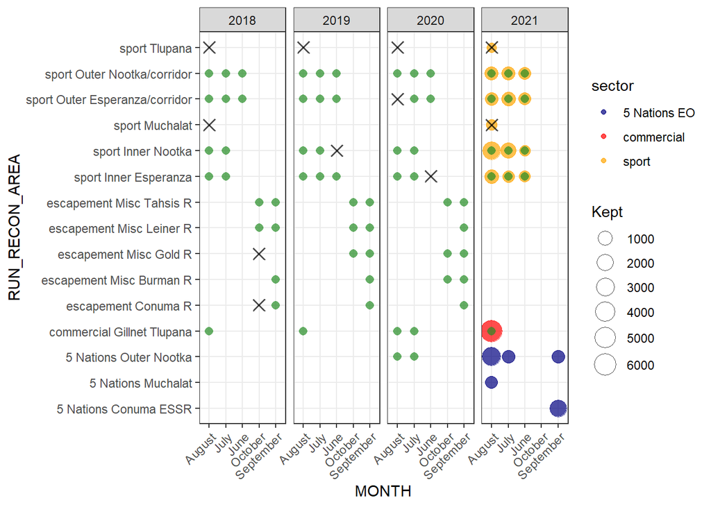

Temporal distribution of catch by sector (blue/red/yellow) and accompanying biological samples (green). Green points indicate >10 samples from a RRA-year; black X indicates <10 samples; no mark accompanying catch indicates no biological samples from that RRA-year.

# 4 Lookup tables